# Personal Activity Machine Learning

Yaniv Fais

Sunday, May 24, 2015

# Background

Using devices such as Jawbone Up, Nike FuelBand, and Fitbit it is now possible to collect a large amount of data about personal activity relatively inexpensively. These type of devices are part of the quantified self movement – a group of enthusiasts who take measurements about themselves regularly to improve their health, to find patterns in their behavior, or because they are tech geeks. One thing that people regularly do is quantify how much of a particular activity they do, but they rarely quantify how well they do it. In this project, your goal will be to use data from accelerometers on the belt, forearm, arm, and dumbell of 6 participants. They were asked to perform barbell lifts correctly and incorrectly in 5 different ways. More information is available from the website here: http://groupware.les.inf.puc-rio.br/har (see the section on the Weight Lifting Exercise Dataset).

# Libraries

The following libraries were used throughout the code.

```r
library(randomForest)
library(kernlab)
library(corrplot)
library(caret)
```

# Loading and preprocessing the data

Two csv files containing the training and test data was downloaded from Amazon’s cloudfront into a folder named ‘data’ in the working directory, the training data was then loaded into R.

```r
data_training <- read.csv("./data/pml-training.csv", na.strings= c("NA",""," "))
```

# Data is then cleaned by removing NR , columns with name, timestamp

```r
data_training_NAs <- apply(data_training, 2, function(x) {sum(is.na(x))})
dataClean <- data_training[,which(data_training_NAs == 0)]
dataClean <- dataClean[8:length(dataClean)]
```

# Creating a model

```r
# split the cleaned testing data into training and cross validation
inTrain <- createDataPartition(y = dataClean$classe, p = 0.7, list = FALSE)
training <- dataClean[inTrain, ]
crossval <- dataClean[-inTrain, ]
```

# Training

Prediction done using a random forest model as it can balance error in unbalanced data sets, the correlation between any two trees in the forest increase the forest error rate. As such we use a correlation plot in order to see how strong the relation between the variables is.

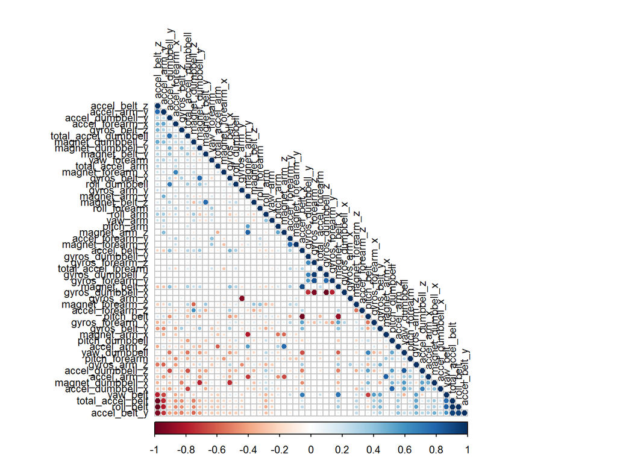

```r
corrMat <- cor(training[, -length(training)])
corrplot(corrMat, order = "FPC", method = "circle", type = "lower", tl.cex = 0.8,  tl.col = rgb(0, 0, 0))
```

```r
model <- randomForest(classe ~ ., data = training)
```

# Cross-validation

```r
predictCrossVal <- predict(model, crossval)
confusionMatrix(crossval$classe, predictCrossVal)
```

```
## Confusion Matrix and Statistics
##
##           Reference
## Prediction    A    B    C    D    E
##          A 1674    0    0    0    0
##          B   12 1122    5    0    0
##          C    0   10 1016    0    0
##          D    0    0   12  951    1
##          E    0    0    0    2 1080
##
## Overall Statistics
##
##                Accuracy : 0.9929
##                  95% CI : (0.9904, 0.9949)
##     No Information Rate : 0.2865
##     P-Value [Acc > NIR] : < 2.2e-16
##
##                   Kappa : 0.991
##  Mcnemar's Test P-Value : NA
##
## Statistics by Class:
##
##                      Class: A Class: B Class: C Class: D Class: E
## Sensitivity            0.9929   0.9912   0.9835   0.9979   0.9991
## Specificity            1.0000   0.9964   0.9979   0.9974   0.9996
## Pos Pred Value         1.0000   0.9851   0.9903   0.9865   0.9982
## Neg Pred Value         0.9972   0.9979   0.9965   0.9996   0.9998
## Prevalence             0.2865   0.1924   0.1755   0.1619   0.1837
## Detection Rate         0.2845   0.1907   0.1726   0.1616   0.1835
## Detection Prevalence   0.2845   0.1935   0.1743   0.1638   0.1839
## Balanced Accuracy      0.9964   0.9938   0.9907   0.9976   0.9993
```

We got >99% accuracy so this seems like a pretty good prediction model based on training, moving on to testing.

# Predictions

The test data is loaded and cleaned similar to the training data.

```r
data_test <- read.csv("./data/pml-testing.csv", na.strings= c("NA",""," "))
data_test_NAs <- apply(data_test, 2, function(x) {sum(is.na(x))})
testClean <- data_test[,which(data_test_NAs == 0)]
testClean <- testClean[8:length(testClean)]
```

We then predict using the training data model

```r
predictTest <- predict(model, testClean)
predictTest
```

```
##  1  2  3  4  5  6  7  8  9 10 11 12 13 14 15 16 17 18 19 20
##  B  A  B  A  A  E  D  B  A  A  B  C  B  A  E  E  A  B  B  B
## Levels: A B C D E
```

# Summary

With the given information it is possible to predict how well someone is doing exercise !